# M505: Intro to AI and Machine Learning

# Submitted by: Abhishek Shahi - GH1025413

## BASIC OUTLINE: The Project is divided into 6 major parts:

### PART A: Project Overview and Problem Statement

### PART B: Data Exploration Discussion

### PART C: Data Preprocessing and Feature Engineering

### PART D: Model Training and Hyperparameter Tuning

### PART E: Model Assessment

### PART F: Business Solution Assessment: Strengths, Limitations, Implications and Recommendations

# PART A

### PROJECT OVERVIEW: SpaceMine is a Space mining company which aims to extract geologically and economically minerals from asteroids in the asteroid belt between Mars and Jupyter.

### Key Idea: When struck by cosmic waves chemical elements in soils and rocks emit uniquely identifiable signatures in the form of gamma rays. This data can help SpaceMine to identify potential mines in the asteroid belt. However, unlike optical and x-rays, gamma rays can not be captured by mirrors. They have the highest frequency and are statistically reconstructed to simulate registration of high energy gamma particles in a ground-based atmospheric Cherenkov gamma telescope using the imaging technique.

### Understanding Business Problem:

### Problem Statement: But, the simulated data has one problem. It consists of primary gamma (Signal) generated data as well as the data from background cosmic waves (noise) by hadron collisions. Separating this data is not humanely possible due to two reasons:

#### 1- The data is not an image but a collection of focal attributes in the form of numbers.

#### 2- The data is huge and processing and predicting individual records is not possible.

### Task: Thus, we need to segregate the two classes i.e., gamma(signal) and hadron(noise) by training a machine learning classification model so that SpaceMine can accurately detect the potential space mining regions and can capitalize on the AI driven business insights.

### Moreover, this pioneering work would unleash a new era of socio-economic boom, which would bring the prices of precious minerals down and promote global prosperity alongwith environment sustainability.

## The relevant data is collected from UCI Machine Learning Repository

### Source of data:

UCI Machine Learning Repository. https://doi.org/10.24432/C52C8B.

### Formulating the problem as a machine learning task

#### As a newly appointed data scientist at SpaceMine I shall make an end-to-end data pipeline starting with evaluating the dataset , wrangling and transforming it and making it ready to train it in multiple machine learning models. I shall train multiple classificatory models to distinguish the signal (gamma) from the noise(hadron) and evaluate it on different model hyper-parameters. I would parallelly evaluate the models with their classification reports to bring out the best possible predictor. Finally, I would provide a business solution highlighting various strengths and limitations of my pipeline and give recommendations on the business solution. This would enable SpaceMine to get a competitive edge with AI driven decision making it identify potential mining areas in the Asteroid Belt.

# PART B

## A data exploration discussion

### Importing necessary libraries and the dataset

```python
# Basic libraries
import numpy as np
import pandas as pd
import statistics
import matplotlib.pyplot as plt
import seaborn as sns
import time

# Data pre-processing libraries
import sklearn
from sklearn.model_selection import train_test_split
from imblearn.over_sampling import RandomOverSampler
from sklearn.preprocessing import MinMaxScaler

# Model training libraries
from sklearn.linear_model import LogisticRegression
from sklearn.naive_bayes import GaussianNB
from sklearn.svm import SVC
from sklearn.neighbors import KNeighborsClassifier
from sklearn.tree import DecisionTreeClassifier
from sklearn.ensemble import RandomForestClassifier
from sklearn.ensemble import GradientBoostingClassifier
from sklearn.ensemble import AdaBoostClassifier
from xgboost import XGBClassifier


# Model evaluation
from sklearn.metrics import classification_report
from sklearn.metrics import roc_auc_score
from sklearn.metrics import make_scorer, precision_score, roc_auc_score

# Hyperparameter tuning
from sklearn.model_selection import GridSearchCV
from sklearn.model_selection import RandomizedSearchCV
from sklearn.model_selection import KFold, cross_val_score

import warnings
warnings.filterwarnings("ignore")
```

```python
df = pd.read_csv(r"C:\Users\Hp\Desktop\magic04.data")
```

```python
df.head()
```

|  | 28.7967 | 16.0021 | 2.6449 | 0.3918 | 0.1982 | 27.7004 | 22.011 | -8.2027 | 40.092 | 81.8828 | g |
| --- | --- | --- | --- | --- | --- | --- | --- | --- | --- | --- | --- |
| 0 | 31.6036 | 11.7235 | 2.5185 | 0.5303 | 0.3773 | 26.2722 | 23.8238 | -9.9574 | 6.3609 | 205.261 | g |
| 1 | 162.0520 | 136.0310 | 4.0612 | 0.0374 | 0.0187 | 116.7410 | -64.8580 | -45.2160 | 76.9600 | 256.788 | g |
| 2 | 23.8172 | 9.5728 | 2.3385 | 0.6147 | 0.3922 | 27.2107 | -6.4633 | -7.1513 | 10.4490 | 116.737 | g |
| 3 | 75.1362 | 30.9205 | 3.1611 | 0.3168 | 0.1832 | -5.5277 | 28.5525 | 21.8393 | 4.6480 | 356.462 | g |
| 4 | 51.6240 | 21.1502 | 2.9085 | 0.2420 | 0.1340 | 50.8761 | 43.1887 | 9.8145 | 3.6130 | 238.098 | g |

### Inference: The dataset has certain data quality issues. The columns are not named, so we shall create a column list and fit in into the dataset as the column list.

```python
columns = ['FL','FW','FS','FC','FC1','FA','FM3L','FM3T','FAlpha','FD','CLASS']
```

```python
df_new = pd.read_csv(r"C:\Users\Hp\Desktop\magic04.data", names = columns)
```

```python
df_new.head()
```

|  | FL | FW | FS | FC | FC1 | FA | FM3L | FM3T | FAlpha | FD | CLASS |
| --- | --- | --- | --- | --- | --- | --- | --- | --- | --- | --- | --- |
| 0 | 28.7967 | 16.0021 | 2.6449 | 0.3918 | 0.1982 | 27.7004 | 22.0110 | -8.2027 | 40.0920 | 81.8828 | g |
| 1 | 31.6036 | 11.7235 | 2.5185 | 0.5303 | 0.3773 | 26.2722 | 23.8238 | -9.9574 | 6.3609 | 205.2610 | g |
| 2 | 162.0520 | 136.0310 | 4.0612 | 0.0374 | 0.0187 | 116.7410 | -64.8580 | -45.2160 | 76.9600 | 256.7880 | g |
| 3 | 23.8172 | 9.5728 | 2.3385 | 0.6147 | 0.3922 | 27.2107 | -6.4633 | -7.1513 | 10.4490 | 116.7370 | g |
| 4 | 75.1362 | 30.9205 | 3.1611 | 0.3168 | 0.1832 | -5.5277 | 28.5525 | 21.8393 | 4.6480 | 356.4620 | g |

```python
### Replacing g --> with 1 and h --> with 0, since XGboost and AUC-ROC requires int type as parameters
```

```python
df_new['CLASS'] = df_new['CLASS'].replace({'g': 1, 'h': 0})
```

```python
df_new.head()
```

|  | FL | FW | FS | FC | FC1 | FA | FM3L | FM3T | FAlpha | FD | CLASS |
| --- | --- | --- | --- | --- | --- | --- | --- | --- | --- | --- | --- |
| 0 | 28.7967 | 16.0021 | 2.6449 | 0.3918 | 0.1982 | 27.7004 | 22.0110 | -8.2027 | 40.0920 | 81.8828 | 1 |
| 1 | 31.6036 | 11.7235 | 2.5185 | 0.5303 | 0.3773 | 26.2722 | 23.8238 | -9.9574 | 6.3609 | 205.2610 | 1 |
| 2 | 162.0520 | 136.0310 | 4.0612 | 0.0374 | 0.0187 | 116.7410 | -64.8580 | -45.2160 | 76.9600 | 256.7880 | 1 |
| 3 | 23.8172 | 9.5728 | 2.3385 | 0.6147 | 0.3922 | 27.2107 | -6.4633 | -7.1513 | 10.4490 | 116.7370 | 1 |
| 4 | 75.1362 | 30.9205 | 3.1611 | 0.3168 | 0.1832 | -5.5277 | 28.5525 | 21.8393 | 4.6480 | 356.4620 | 1 |

### Checking for missing values:

```python
df_new.isna().sum()
```

```
FL        0
FW        0
FS        0
FC        0
FC1       0
FA        0
FM3L      0
FM3T      0
FAlpha    0
FD        0
CLASS     0
dtype: int64
```

### Inference no missing values

```python
# Checking for outliers
df_new.describe().T
```

|  | count | mean | std | min | 25% | 50% | 75% | max |
| --- | --- | --- | --- | --- | --- | --- | --- | --- |
| FL | 19020.0 | 53.250154 | 42.364855 | 4.2835 | 24.336000 | 37.14770 | 70.122175 | 334.1770 |
| FW | 19020.0 | 22.180966 | 18.346056 | 0.0000 | 11.863800 | 17.13990 | 24.739475 | 256.3820 |
| FS | 19020.0 | 2.825017 | 0.472599 | 1.9413 | 2.477100 | 2.73960 | 3.101600 | 5.3233 |
| FC | 19020.0 | 0.380327 | 0.182813 | 0.0131 | 0.235800 | 0.35415 | 0.503700 | 0.8930 |
| FC1 | 19020.0 | 0.214657 | 0.110511 | 0.0003 | 0.128475 | 0.19650 | 0.285225 | 0.6752 |
| FA | 19020.0 | -4.331745 | 59.206062 | -457.9161 | -20.586550 | 4.01305 | 24.063700 | 575.2407 |
| FM3L | 19020.0 | 10.545545 | 51.000118 | -331.7800 | -12.842775 | 15.31410 | 35.837800 | 238.3210 |
| FM3T | 19020.0 | 0.249726 | 20.827439 | -205.8947 | -10.849375 | 0.66620 | 10.946425 | 179.8510 |
| FAlpha | 19020.0 | 27.645707 | 26.103621 | 0.0000 | 5.547925 | 17.67950 | 45.883550 | 90.0000 |
| FD | 19020.0 | 193.818026 | 74.731787 | 1.2826 | 142.492250 | 191.85145 | 240.563825 | 495.5610 |
| CLASS | 19020.0 | 0.648370 | 0.477492 | 0.0000 | 0.000000 | 1.00000 | 1.000000 | 1.0000 |

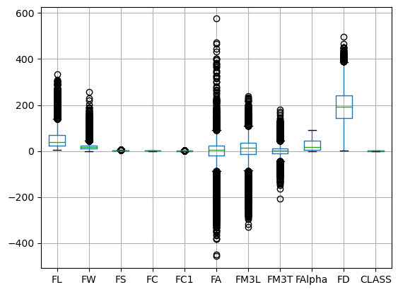

```python
df_new.boxplot()
plt.show()
```

### Inference: Outliers are present

```python
def outlier(data):
    anomaly = []
    sd = statistics.stdev(data)
    mean = statistics.mean(data)
    cutoff = sd*3
    for item in data:
        if item > mean+cutoff or item < mean-cutoff:
            anomaly.append(item)
    return anomaly
```

```python
anomaly = outlier(df_new['FL'])
```

```python
len(anomaly)
```

```
431
```

```python
anomaly2 = outlier(df_new['FA'])
```

```python
len(anomaly2)
```

```
421
```

### We are not removing the outliers since we are training a classification model and we want our model to be trained on extreme cases as well, to make it more robust and prevent over-fitting. Moreover, these outliers provide significant information in classifying a Class as Gamma (signal) or Hadron(noise). Removing them will lead to information loss and make our model susceptible to overfitting and linearity. We want our model to have high variance (complex) and at the same time low bias, so that it understands the complex nature of our data samples but also gives less error.

### Checking fo data invalidity issues

```python
df_new.info()
```

```
<class 'pandas.core.frame.DataFrame'>
RangeIndex: 19020 entries, 0 to 19019
Data columns (total 11 columns):
 #   Column  Non-Null Count  Dtype
---  ------  --------------  -----
 0   FL      19020 non-null  float64
 1   FW      19020 non-null  float64
 2   FS      19020 non-null  float64
 3   FC      19020 non-null  float64
 4   FC1     19020 non-null  float64
 5   FA      19020 non-null  float64
 6   FM3L    19020 non-null  float64
 7   FM3T    19020 non-null  float64
 8   FAlpha  19020 non-null  float64
 9   FD      19020 non-null  float64
 10  CLASS   19020 non-null  int64
dtypes: float64(10), int64(1)
memory usage: 1.6 MB
```

```python
df_new.shape
```

```
(19020, 11)
```

### Checking for duplicates

```python
duplicates = df_new[df_new.duplicated()]
print(duplicates)
```

```
             FL       FW      FS      FC     FC1        FA      FM3L     FM3T  \
12827  202.8290  73.9967  4.3622  0.0678  0.0364  -66.4079 -159.3540 -21.2584
13332   30.1721  16.8838  2.6902  0.4673  0.2704    8.8759   25.3694  14.0300
13486   69.7676  18.9821  2.7478  0.5255  0.2654  -44.5832  -30.7591 -12.9547
14150  130.3080  13.3030  2.6021  0.3250  0.1812 -204.5730  116.0500   4.7837
14160   16.9894  11.0002  2.4564  0.6294  0.3514   -3.4902    8.0823  -7.0516
...         ...      ...     ...     ...     ...       ...       ...      ...
18809   60.5328  34.9208  3.0436  0.2732  0.1750  -39.5703   45.4899 -28.7449
18826   38.7641  20.0218  2.6279  0.2921  0.1543  -49.9354  -21.7010 -13.0915
18831   22.2134  18.3853  2.5653  0.4354  0.2599  -16.5600   16.1254  13.1403
18929   19.8489  12.8985  2.3847  0.5567  0.3155  -12.1732  -10.7301   7.9112
19001   57.1905  35.5095  2.7177  0.2337  0.1197  -48.5112  -54.2835  32.3612

        FAlpha        FD  CLASS
12827  76.1130  348.9780      0
13332  74.7090  229.2960      0
13486  33.0052  303.9140      0
14150  49.7590  173.5520      0
14160  55.3930   91.3761      0
...        ...       ...    ...
18809   0.8124  290.6000      0
18826  19.7802  136.9650      0
18831  23.6480   93.1750      0
18929  55.0925  168.9720      0
19001  44.7320  102.9950      0

[115 rows x 11 columns]
```

```python
duplicates.shape
```

```
(115, 11)
```

### We shall drop the duplicates now (before splitting to prevent any data leakage)

```python
df_new = df_new.drop_duplicates()
```

```python
df_new.shape
```

```
(18905, 11)
```

### Splitting the data before sampling to prevent any data leakage

```python
X = df_new.drop('CLASS', axis=1)
y = df_new['CLASS']
```

```python
X_train, X_test, y_train, y_test = sklearn.model_selection.train_test_split(X , y , test_size=0.2, random_state=42)
```

## Does the dataset require any sampling or balancing techniques?

```python
df_new['CLASS'].value_counts()
```

```
CLASS
1    12332
0     6573
Name: count, dtype: int64
```

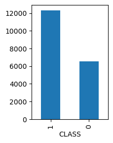

```python
df_new['CLASS'].value_counts().plot(kind ='bar', figsize = (2,3))
plt.show()
```

### Inference: The dataset is imbalance since the class g (gamma/signal) is over-represented. This can create a bias in our model for gamma predictions. Thus, we can either under-sample it or oversample h (hadron) class. Since, we only have 18905 records left and under-sampling might lead to information loss so we prefer to do oversampling of 'h' class.

```python
over_sampler = RandomOverSampler()
```

```python
X_os, y_os = over_sampler.fit_resample(X_train,y_train)
```

```python
X_os.shape
```

```
(19692, 10)
```

```python
y_os.shape
```

```
(19692,)
```

### The dataset is now oversampled and has 19692 records. We didn't use sampling on test data to prevent data leakage. Also, we did sampling after splitting the data to prevent the same.

## Which evaluation metrics fit this dataset?

### Explaining the dataset dependent and independent features (columns)

### INDEPENDENT VARIABLES (10)

#### 1. FL: (FOCAL LENGTH): Ellipse major axis in mm

#### 2. FW: (FOCAL WIDTH): Ellipse minor axis in mm

#### 3. FS: (SIZE): Log (Sum of all pixel values)

#### 4. FC: Sum of two highest pixels / FS

#### 5. FC1: Highest pixel / FS

#### 6. FA: Distance from highest pixel to center, projected onto major axis in mm

#### 7. FM3L: 3rd root of 3rdment along major axis in mm

#### 8. FM3T: 3rd root of 3rd moment of minor axis in mm

#### 9. FAlpha: Angle of major axis with vector to origin in degrees

#### 10. FD: Distance from origin to center of ellipse in mm

### DEPENDENT TARGET VARIABLE:

#### CLASS: g,h for gamma (SIGNAL) and hadron (NOISE)

This is a classification problem and various classification metrics like accuracy, precision, recall, Area under ROC curve will be evaluated. However, accuracy is not meaningful here because classifying a hadron(noise) as gamma(signal) will waste SpaceMine's time, money and resources in pursuing a futile exploration due to our misclassification. Hence, we need to minimize False Positives. We give priority to PRECISION when the cost of False Positive is high (in this case) and we prioritize RECALL when the cost of False Negative is high (eg. Cancer Prediction, Spam, etc). The cost of false negative is not very high, since even if we miss some potential areas it will not cost SpaceMine significant costs because there are many potential sites. Thus, PRECISION is vital here. Also AUC-ROC will be given importance during model evaluation step to evaluate the overall performance of the model.This is significant as AUC-ROC is scale-invariant and is a key measure when class is im-balanced and when the cost of False Positive and False Negative are different as in this case.

### KEY METRIC IN OUR FOCUS: PRECISION AND AUC-ROC

### The data is valid for further processing i.e Feature scaling, encoding, feature reduction using PCA, etc if necessary

# PART C

### Further Preprocessing, Splitting and feature engineering steps to prepare the dataset for learning.

### Since all the columns are of numerical type we don't need to do feature encoding. Also the features will not increase which usually happens due to feature encoding so we dont need to do Dimensionality Reduction as well. We will go towards Feature Scaling so that our model is independent of the absolute values in our features and thus is free from magnitude bias.

```python
X_os.head()
```

|  | FL | FW | FS | FC | FC1 | FA | FM3L | FM3T | FAlpha | FD |
| --- | --- | --- | --- | --- | --- | --- | --- | --- | --- | --- |
| 0 | 191.5672 | 80.6114 | 3.7321 | 0.1480 | 0.0721 | 24.5414 | -275.0622 | 52.3232 | 33.2709 | 358.7917 |
| 1 | 18.2881 | 12.9890 | 2.4023 | 0.5149 | 0.2673 | -14.2768 | -7.2290 | -3.9326 | 48.0394 | 157.5260 |
| 2 | 17.9634 | 10.2982 | 2.2765 | 0.6561 | 0.3413 | 21.5137 | 11.0116 | -6.4360 | 37.5250 | 153.1340 |
| 3 | 28.4509 | 6.2218 | 2.4378 | 0.6752 | 0.4325 | -27.3687 | -23.7230 | 3.7167 | 9.2887 | 233.0440 |
| 4 | 10.5046 | 9.0132 | 2.2204 | 0.6088 | 0.3293 | 6.8141 | 10.3285 | -5.9923 | 69.4158 | 150.3847 |

```python
y_os.head()
```

```
0    0
1    1
2    1
3    1
4    0
Name: CLASS, dtype: int64
```

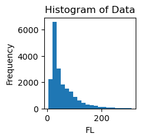

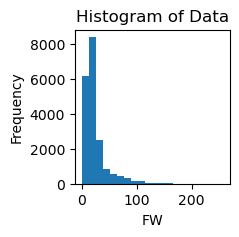

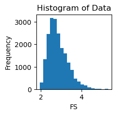

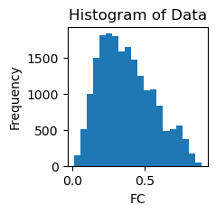

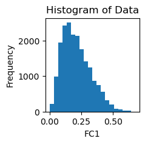

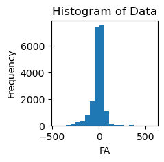

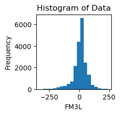

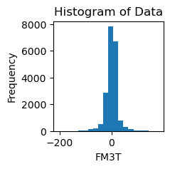

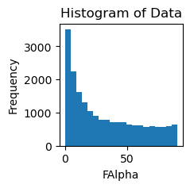

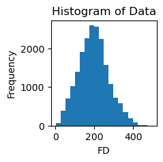

```python
for f in X_os:
    plt.figure(figsize=(2,2))
    plt.hist(X_os[f], bins=20)
    plt.xlabel(f)
    plt.ylabel('Frequency')
    plt.title('Histogram of Data')
    plt.show()
```

### As can be seen from the above plots FL, FW, FAlpha are not normally distributed. Thus, we will go with Min-Max scaling since it supports non-gaussian data and is also helpful for interpretability. MOreover, we also know the min -max values and it is robust to outliers. (We didn't remove the outliers, hence this perspective also has to be kept in mind)

```python
scaler = MinMaxScaler()
```

```python
# Scaling X train and X test separately
X_train_scaled = scaler.fit_transform(X_train)
X_test_scaled = scaler.transform(X_test)
```

### Now the dataset is fit to be trained on multiple models and based on Key metrics PRECISION AND AUC-ROC , we shall evaluate our models. The reasons to chose these key metrics has been stated before. Further, we shall also do hyper-parameter tuning using grid-search to get the best model hyperparameters and use k-fold cross validation to check for model performance.

# PART D

### Model training step to select the best machine learning algorithm using high precision for 'g' and high recall for 'h', since we do not want a scenario when the model predicts a gamma and it is not a gamma in reality OR a situation when the model does not predict 'h', when it is in reality 'h'. We also consider the AUC-ROC curve since a higher value of this parameter indicates a higher discrimination ability, which is what we exactly need in a classification predictive model.

### 1: Logistic Regression

```python
logistic_model = LogisticRegression()
```

```python
logistic_model = logistic_model.fit(X_train,y_train)
```

```python
y_pred = logistic_model.predict(X_test)
```

```python
print(classification_report(y_test, y_pred))
auc_roc = roc_auc_score(y_test, y_pred)
print("AUC-ROC Score:", auc_roc)
```

```
              precision    recall  f1-score   support

           0       0.74      0.59      0.65      1295
           1       0.81      0.89      0.85      2486

    accuracy                           0.79      3781
   macro avg       0.77      0.74      0.75      3781
weighted avg       0.78      0.79      0.78      3781

AUC-ROC Score: 0.7391483426881658
```

### 2: Naive bayes

```python
nb_model = GaussianNB()
```

```python
nb_model = nb_model.fit(X_train, y_train)
```

```python
y_pred = nb_model.predict(X_test)
```

```python
print(classification_report(y_test, y_pred))
auc_roc = roc_auc_score(y_test, y_pred)
print("AUC-ROC Score:", auc_roc)
```

```
              precision    recall  f1-score   support

           0       0.71      0.38      0.49      1295
           1       0.74      0.92      0.82      2486

    accuracy                           0.73      3781
   macro avg       0.73      0.65      0.66      3781
weighted avg       0.73      0.73      0.71      3781

AUC-ROC Score: 0.649551154418411
```

### 3: Support Vector Machines

```python
svm_model = SVC()
```

```python
svm_model = svm_model.fit(X_train,y_train)
```

```python
y_pred = svm_model.predict(X_test)
```

```python
print(classification_report(y_test, y_pred))
auc_roc = roc_auc_score(y_test, y_pred)
print("AUC-ROC Score:", auc_roc)
```

```
              precision    recall  f1-score   support

           0       0.87      0.58      0.69      1295
           1       0.81      0.95      0.88      2486

    accuracy                           0.83      3781
   macro avg       0.84      0.77      0.79      3781
weighted avg       0.83      0.83      0.81      3781

AUC-ROC Score: 0.7662607901545956
```

### 4: KNN model

```python
knn_model = KNeighborsClassifier(n_neighbors = 3)
```

```python
knn_model.fit(X_train, y_train)
```

```
KNeighborsClassifier(n_neighbors=3)
```

```python
y_pred = knn_model.predict(X_test)
```

```python
print(classification_report(y_test, y_pred))
auc_roc = roc_auc_score(y_test, y_pred)
print("AUC-ROC Score:", auc_roc)
```

```
              precision    recall  f1-score   support

           0       0.77      0.61      0.68      1295
           1       0.82      0.91      0.86      2486

    accuracy                           0.80      3781
   macro avg       0.79      0.76      0.77      3781
weighted avg       0.80      0.80      0.80      3781

AUC-ROC Score: 0.7583256972637504
```

### 5: Decision Trees

```python
dt = DecisionTreeClassifier(random_state=42)
dt.fit(X_train, y_train)
```

```
DecisionTreeClassifier(random_state=42)
```

```python
y_pred = dt.predict(X_test)
```

```python
print(classification_report(y_test, y_pred))
auc_roc = roc_auc_score(y_test, y_pred)
print("AUC-ROC Score:", auc_roc)
```

```
              precision    recall  f1-score   support

           0       0.75      0.72      0.74      1295
           1       0.86      0.88      0.87      2486

    accuracy                           0.82      3781
   macro avg       0.81      0.80      0.80      3781
weighted avg       0.82      0.82      0.82      3781

AUC-ROC Score: 0.8006175121219368
```

### 6: Ensemble Models : Random Forest

```python
rf = RandomForestClassifier(n_estimators=100, random_state=42)
rf.fit(X_train, y_train)
```

```
RandomForestClassifier(random_state=42)
```

```python
y_pred = rf.predict(X_test)
```

```python
print(classification_report(y_test, y_pred))
auc_roc = roc_auc_score(y_test, y_pred)
print("AUC-ROC Score:", auc_roc)
```

```
              precision    recall  f1-score   support

           0       0.86      0.77      0.81      1295
           1       0.89      0.94      0.91      2486

    accuracy                           0.88      3781
   macro avg       0.88      0.85      0.86      3781
weighted avg       0.88      0.88      0.88      3781

AUC-ROC Score: 0.8531802806139089
```

### 7: Ensemble Models : Gradient Boosting

```python
gb = GradientBoostingClassifier(n_estimators=100, random_state=42)
gb.fit(X_train, y_train)
```

```
GradientBoostingClassifier(random_state=42)
```

```python
y_pred = gb.predict(X_test)
```

```python
print(classification_report(y_test, y_pred))
auc_roc = roc_auc_score(y_test, y_pred)
print("AUC-ROC Score:", auc_roc)
```

```
              precision    recall  f1-score   support

           0       0.89      0.74      0.81      1295
           1       0.88      0.95      0.91      2486

    accuracy                           0.88      3781
   macro avg       0.88      0.85      0.86      3781
weighted avg       0.88      0.88      0.88      3781

AUC-ROC Score: 0.8467061878566303
```

### 8: Ensemble Models : AdaBoost

```python
adb = AdaBoostClassifier(n_estimators=100, random_state=42)
adb.fit(X_train, y_train)
```

```
AdaBoostClassifier(n_estimators=100, random_state=42)
```

```python
y_pred = adb.predict(X_test)
```

```python
print(classification_report(y_test, y_pred))
auc_roc = roc_auc_score(y_test, y_pred)
print("AUC-ROC Score:", auc_roc)
```

```
              precision    recall  f1-score   support

           0       0.81      0.72      0.77      1295
           1       0.86      0.91      0.89      2486

    accuracy                           0.85      3781
   macro avg       0.84      0.82      0.83      3781
weighted avg       0.85      0.85      0.85      3781

AUC-ROC Score: 0.8181316530874054
```

### 9: Ensemble Models : XGBoost

```python
xgb = XGBClassifier(booster='gbtree', n_estimators=100, random_state=42)
xgb.fit(X_train, y_train)
```

```
XGBClassifier(base_score=None, booster='gbtree', callbacks=None,
              colsample_bylevel=None, colsample_bynode=None,
              colsample_bytree=None, device=None, early_stopping_rounds=None,
              enable_categorical=False, eval_metric=None, feature_types=None,
              gamma=None, grow_policy=None, importance_type=None,
              interaction_constraints=None, learning_rate=None, max_bin=None,
              max_cat_threshold=None, max_cat_to_onehot=None,
              max_delta_step=None, max_depth=None, max_leaves=None,
              min_child_weight=None, missing=nan, monotone_constraints=None,
              multi_strategy=None, n_estimators=100, n_jobs=None,
              num_parallel_tree=None, random_state=42, ...)
```

```python
y_pred = xgb.predict(X_test)
print(classification_report(y_test, y_pred))
auc_roc = roc_auc_score(y_test, y_pred)
print("AUC-ROC Score:", auc_roc)
```

```
              precision    recall  f1-score   support

           0       0.89      0.78      0.83      1295
           1       0.89      0.95      0.92      2486

    accuracy                           0.89      3781
   macro avg       0.89      0.87      0.88      3781
weighted avg       0.89      0.89      0.89      3781

AUC-ROC Score: 0.8659465982474832
```

#### 4- It is less sensitive to outliers.

### However, we will also hyparameter tune XGBoost and if there is a considerable increase in Precision and AUC-ROC score then we will switch to XGBoost

# PART E

### A model assessment step to evaluate the final performance of the best trained model: RandomForest VS XGBoost

### Checking for overfitting for Random Forest

```python
train_acc = rf.score(X_train, y_train)
test_acc = rf.score(X_test, y_test)
print("Train Accuracy:", train_acc)
print("Test Accuracy:", test_acc)
```

```
Train Accuracy: 1.0
Test Accuracy: 0.8796614652208411
```

### Model is over-fitting since train and test accuracy differential is high

### Checking for Overfitting for XGBoost

```python
train_acc = xgb.score(X_train, y_train)
test_acc = xgb.score(X_test, y_test)
print("Train Accuracy:", train_acc)
print("Test Accuracy:", test_acc)
```

```
Train Accuracy: 0.9627743983073261
Test Accuracy: 0.8918275588468659
```

### Model is slightly over-fitting. The Overfitting is more for RandomForest.

## Generally GridSearchCV is used for random forest because the number of hyper-parameters in RandomForest are less and thus an exhaustive search is possible. However, here we will be using RandomizedSearchCV for both RandomForest and XGBoost since the hyperparameters search space is more in and computational resources are limited. For cross validation we will divide the data into 5 equal size folds by setting the hyper-parameter cv=5. After this we will also do k-fold cross validation.

### RandomSearchCV For Optimising PRECISION IN Random_Forest

```python
parameters_grid = {
    'n_estimators': [100, 200, 300],
    'max_depth': [5,9,13],
    'min_samples_split': [2, 5],
    'min_samples_leaf': [1, 2]
}

rf = RandomForestClassifier(random_state=42)
s = time.time()

random_search_rf = RandomizedSearchCV(rf, parameters_grid, cv=5, scoring='precision')
random_search_rf.fit(X_train, y_train)
e = time.time()
Time_taken = e - s

print("Best Precision achieved from the above combination of hyper-parameters:", random_search_rf.best_score_)
print("Best Hyper-Parameters discovered:", random_search_rf.best_params_)
print("Time taken by the algorithm:", Time_taken )
```

```
Best Precision achieved from the above combination of hyper-parameters: 0.8694979039733015
Best Hyper-Parameters discovered: {'n_estimators': 300, 'min_samples_split': 5, 'min_samples_leaf': 1, 'max_depth': 13}
Time taken by the algorithm: 381.450510263443
```

### RandomSearchCV For optimising AUC-ROC IN Random_Forest

```python
parameters_grid = {
    'n_estimators': [100, 200, 300],
    'max_depth': [5,9,13],
    'min_samples_split': [2, 5],
    'min_samples_leaf': [1, 2]
}


rf = RandomForestClassifier(random_state=48)
s = time.time()

random_search_rf = RandomizedSearchCV(rf, parameters_grid, cv=5, scoring='roc_auc')
random_search_rf.fit(X_train, y_train)
e = time.time()
Time_taken = e - s

print("Best AUC ROC achieved from the above combination of hyper-parameters:", random_search_rf.best_score_)
print("Best Hyper-Parameters discovered:", random_search_rf.best_params_)
print("Time taken by the algorithm:", Time_taken )
```

```
Best AUC ROC achieved from the above combination of hyper-parameters: 0.9303345753358299
Best Hyper-Parameters discovered: {'n_estimators': 200, 'min_samples_split': 2, 'min_samples_leaf': 1, 'max_depth': 13}
Time taken by the algorithm: 314.43016815185547
```

### RandomSearchCV For optimising PRECISION IN XGBoost

```python
parameters_dist = {
    'n_estimators': [100, 200, 300],
    'max_depth': [5,9,13],
    'learning_rate': [0.01, 0.1, 0.2],
    'subsample': [0.8, 0.9, 1.0],
    'colsample_bytree': [0.8, 0.9, 1.0]
}


xgb = XGBClassifier(random_state=48)
s = time.time()

random_search_xgb = RandomizedSearchCV(xgb, parameters_dist, n_iter=10, cv=5, scoring='precision', random_state=48)
random_search_xgb.fit(X_train, y_train)
e = time.time()
Time_taken = e - s

print("Best Precision achieved from the above combination of hyper-parameters:", random_search_xgb.best_score_)
print("Best Hyper-Parameters discovered:", random_search_xgb.best_params_)
print("Time taken by the algorithm:", Time_taken )
```

```
Best Precision achieved from the above combination of hyper-parameters: 0.8822678912138786
Best Hyper-Parameters discovered: {'subsample': 0.9, 'n_estimators': 100, 'max_depth': 13, 'learning_rate': 0.2, 'colsample_bytree': 0.8}
Time taken by the algorithm: 55.76197838783264
```

### RandomSearchCV For optimising AUC-ROC IN XGBoost

```python
parameters_dist = {
    'n_estimators': [100, 200, 300],
    'max_depth': [5,9,13],
    'learning_rate': [0.01, 0.1, 0.2],
    'subsample': [0.8, 0.9, 1.0],
    'colsample_bytree': [0.8, 0.9, 1.0]
}


xgb = XGBClassifier(random_state=48)
s = time.time()

random_search_xgb = RandomizedSearchCV(xgb, parameters_dist, n_iter=10, cv=5, scoring='roc_auc', random_state=48)
random_search_xgb.fit(X_train, y_train)
e = time.time()
Time_taken = e - s

print("Best AUC ROC achieved from the above combination of hyper-parameters:", random_search_xgb.best_score_)
print("Best Hyper-Parameters discovered:", random_search_xgb.best_params_)
print("Time taken by the algorithm:", Time_taken )
```

```
Best AUC ROC achieved from the above combination of hyper-parameters: 0.9339806937212234
Best Hyper-Parameters discovered: {'subsample': 0.8, 'n_estimators': 200, 'max_depth': 5, 'learning_rate': 0.1, 'colsample_bytree': 0.9}
Time taken by the algorithm: 55.27217507362366
```

```python
rf = RandomForestClassifier(n_estimators=300, random_state=48, min_samples_split = 2, min_samples_leaf = 2, max_depth = 13)
kfold = KFold(n_splits=5, shuffle=True, random_state=48)
cv_scores_rf = cross_val_score(rf, X_train, y_train, cv=kfold, scoring='precision')
print("Cross-Validation Scores:", cv_scores_rf)
print("Mean Precision:", cv_scores_rf.mean())
```

```
Cross-Validation Scores: [0.87488372 0.87794533 0.86130374 0.87069767 0.85588099]
Mean Precision: 0.8681422920651671
```

```python
xgb = XGBClassifier(n_estimators=100, random_state=48, subsample = 0.8, max_depth = 13, learning_rate = 0.2, colsample_bytree = 0.8)
kfold = KFold(n_splits=5, shuffle=True, random_state=48)
cv_scores_xgb = cross_val_score(xgb, X_train, y_train, cv=kfold, scoring='precision')
print("Cross-Validation Scores:", cv_scores_xgb)
print("Mean Precision:", cv_scores_xgb.mean())
```

```
Cross-Validation Scores: [0.88606989 0.88668281 0.87956377 0.87842952 0.86761905]
Mean Precision: 0.879673007607642
```

### Thus on final evaluation we chose to go with XGBoost because it is offering better speed as well as performing better in the key metrics like PRECISION (87.9) as compared to 86.8 of RandomForest . Moreover, the overfitting is less in XGBoost.

# PART F

### A final discussion on the overall pipeline. Strengths, Limitations and Recommendations. What are the most informative features of your model? Is your model explainable?

#### The overall pipeline is based on the classification problem of classifying the target variable into Gamma (signal) or Hadron (noise). It covers the major models and evaluation criterias.

#### Strengths :

#### 1- Data has been pre-processed and can be validated.

#### 2- Covers most of the classification models and evaluation metrics.

#### 3- The solution picks the right evalution metric i.e. precision and auc-roc

#### 4- The problem statement and task at hand is well defined

#### 5- XGBoost uses parallel and distributed computing. Thus, it is fast and can be integrated dynamically during model deployment using Flask and Heroku.

#### Limitations:

#### 1- The proposed solution requires more hyperparameter tuning which was deterred by less computational power. Eg GridSearch was taking a lot of time

#### 2- The use of neural networks can also be done. However, for this dataset it would not be the right trade-off.

#### 3- More data can be helpful to decrease over-fitting and help in increasing the predictive power of the model.

#### 4- The final model uses XGBoost which is less interpretable as compared to other models like logistic rregression and Random Forest. It is considered a black box model.

#### 5- Lasso and Ridge regularization can also be used with XGBoost to reduce overfitting and improve generalization performance.

#### Recommendations:

#### 1- A higher ROC-AUC metric shows that the model is better in distinguishing between the two classes. Hence, SpaceMine can trust the machine learning model.

#### 2- It can create a full-fledged report from these results to improve investor confidence.

#### 3- A higher Recall can help SpaceMine to discover other potential sites by decreasing the False Negatives and a higher Precision can help SpaceMine to not undertake futile explorations

#### 4- SpaceMine should target on creating a full data warehouse so that more features can be measured which can help in better predictions. However, SpaceMine should focus more on the state of the art technology to retrieve precious minerals once it gets a nod of the potential site from the model.

#### 5- The prediciton once made should be cross-validated with other models and hyper-parameters.

#### 6- As data will grow SpaceMine should switch to other models as XGBoost is memory intensive in nature due to the size of its hyparameter space.